# Class 7: Machine Learning (Part I)

```r
attributes(pca)
```

```
## $names
## [1] "sdev"     "rotation" "center"   "scale"    "x"
##
## $class
## [1] "prcomp"
```

We can now view a plot of the data along the two most important axes as found through PCA. A plot of PC1 vs PC2 is often called a PCA plot or “score plot”. The x component of the prcomp() output gives the data for such a score plot.

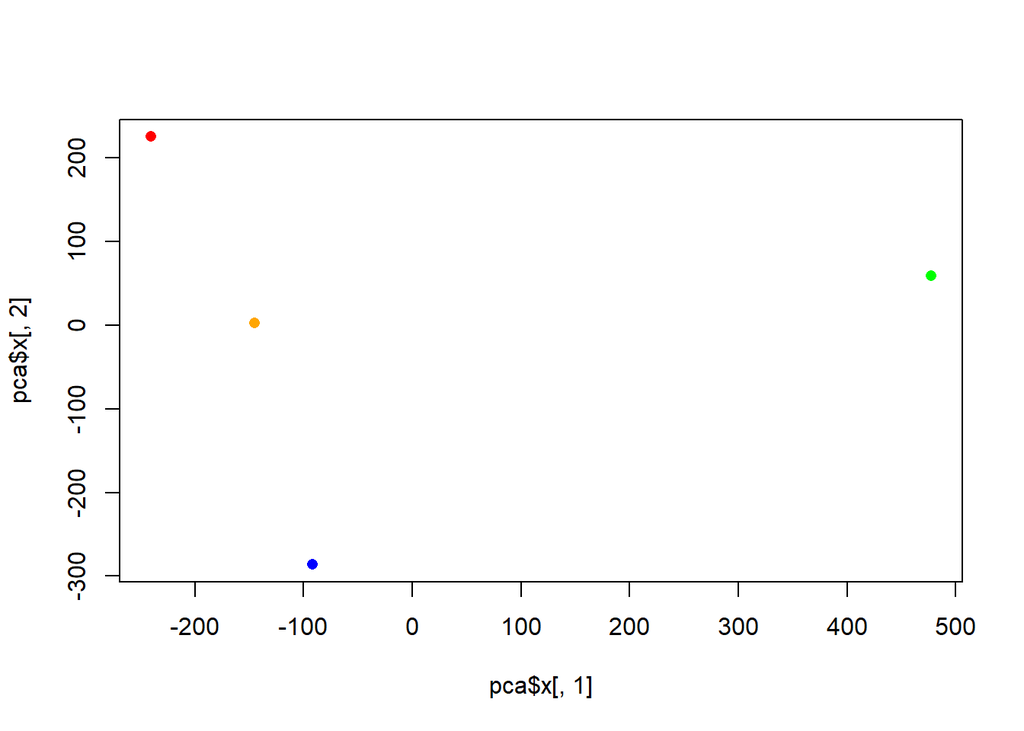

```r
plot(pca$x[,1], pca$x[,2], col = c("Orange", "Red", "Blue", "Green"), pch = 16) #Note order is England, Wales, Scotland, N.Ireland
```

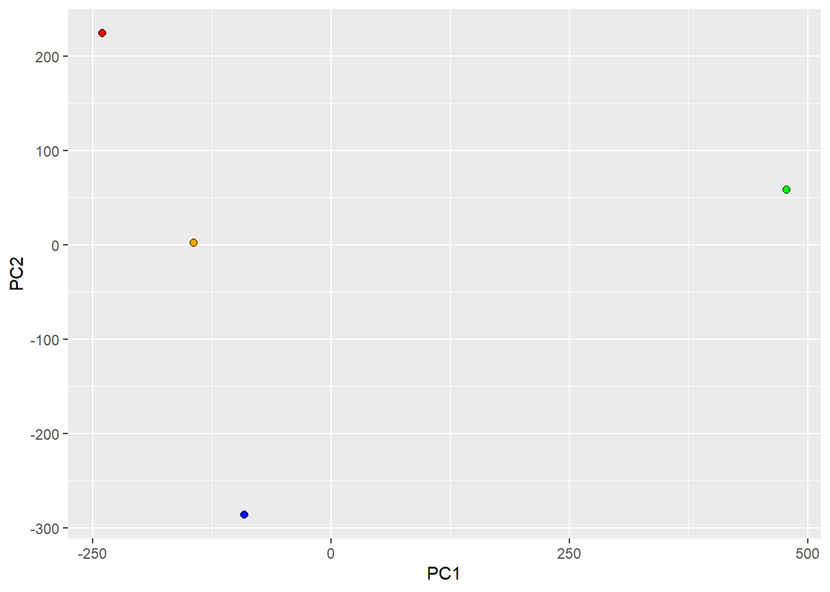

```r
##Need to try plot with ggplot...
p <- as.data.frame(pca$x)

ggplot(p, aes(PC1, PC2)) +
  geom_point(fill = c("Orange", "Red", "Blue", "Green"), pch = 21, size = 2)
```

```r
#   NOW LABEL POINTS!!!!!!!
```

The four points are the four countries. Note the the large distance between one point (N.Ireland) versus the other three (England, Wales and Scotland) on the PC1 axis, which explains the most variation. Note that another important point is to show how much these axes actually contribute to the variation (the loadings), these are found in the component rotation. As PC1 explains most of the variation, we will focus on this.

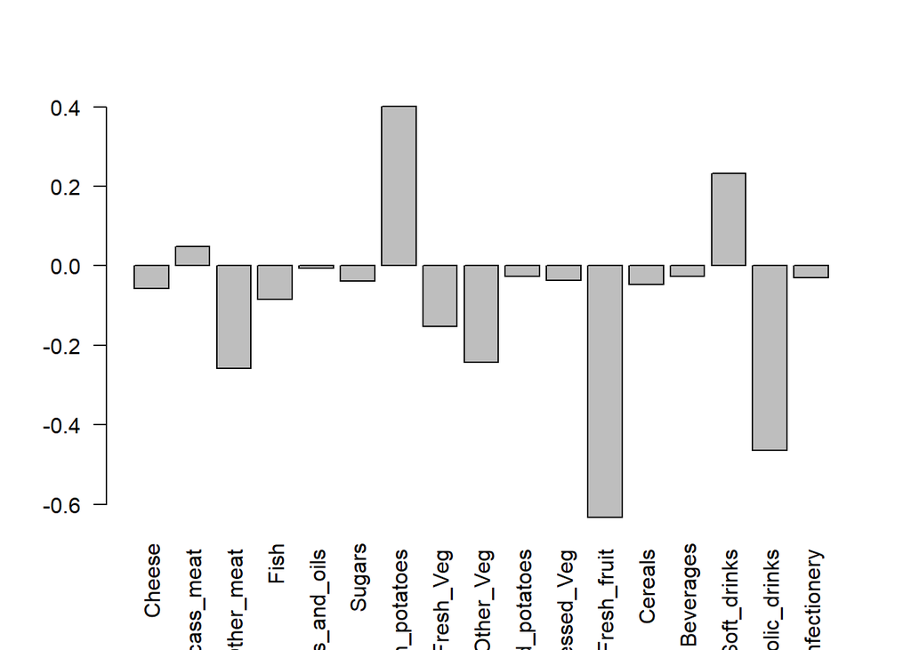

```r
barplot(pca$rotation[,1], las=2)
```

DOUBLE CHECK ALL YOUR WORK AS KEPT GETTING DISTRACTED TRYING TO MAKE GGPLOT WORK, SO NEED TO CHECK DIDN’T GET THINGS WRONG OR MISS THINGS